# Taller 2

```python
import pandas as pd
import numpy as np
import seaborn as sns
import networkx as nx
from pyvis.network import Network
import matplotlib.pyplot as plt
```

```python
G = nx.read_gml('polbooks.gml')
```

```python
print("Número de nodos:", G.number_of_nodes())
print("Número de redes:", G.number_of_edges())
```

```
Número de nodos: 105
Número de redes: 441
```

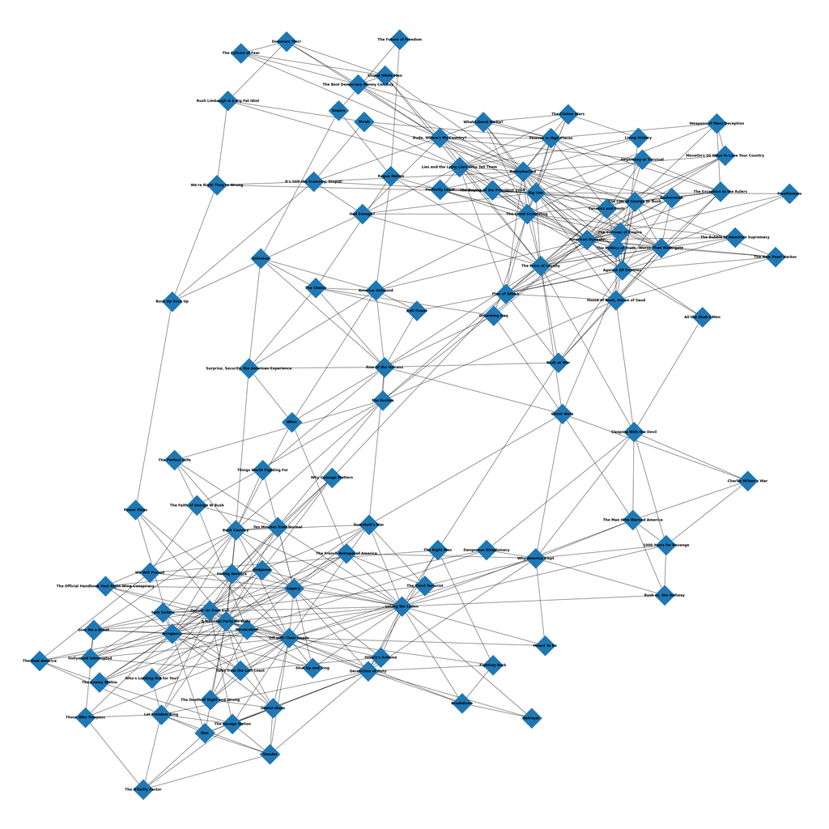

```python
plt.figure(figsize=(40,40))
nx.draw(G,with_labels=True,
        node_shape="D",
        font_weight='bold',
       pos=nx.spring_layout(G,seed=13),
       node_size=2500,
       edge_cmap=plt.cm.magma)
plt.show()
```

#### Contexto de los datos:

Una red de libros sobre política estadounidense publicados alrededor de la época de las elecciones presidenciales de 2004 y vendidos por la librería en línea Amazon.com. Los enlaces entre los libros representan la compra frecuente de libros por los mismos compradores. La red fue compilada por V. Krebs y no está publicada, pero se puede encontrar en el sitio web de Krebs. Gracias a Valdis Krebs por el permiso para publicar estos datos en este sitio web.

### ¿Que?

Lo que se puede ver en este diagrama son los 105 libros que más se vendieron en la epoca de las elecciones presidenciales en el año 2004 en Estado Unidos que estan en los nodos, representando a través de los enlaces la compra frecuente de los mismos usuarios de Amazon, siendo que los libros más populares y que tienen más conexiones entre los usuarios son The price of loyalty, American Disnaty y A National Party No More.

### ¿Cómo?

La base de datos estaba compuesta de nodos y enlaces por lo que la visualización de red era optima para este caso, en este caso no se opta por hacer que la visualización sea interactiva debido a la gran cantidad de nodos que al ser manipulados los enlaces y los demás nodos se moverian de tal forma que determinar las conexiones sería aun más dificil.

### Marca

La marca implementada son los enlaces, ya que estos son los que unen los diferentes nodos por lo que se pueden relacionar las frecuencias de la compra de libros por los mismos usuarios.

### Canal

El canal efectuado en la visualización es de conexión ya que usando la marca de enlaces podemos a través de las lineas del canal identificar que nodo esta conectado a los demás, por lo que esta misma visualización no esta dirigida debido a que no hay una sucesión en las frecuencias

### Cumplimiento de reglas

El 2D esta justificado debido a que no se cuentan con más variables para poder ver si hay relaciones más fuertes que otras o alguna separación de los nodos por categorias. No se implementa una visualización en 3D debido a que al ser demasiados nodos el agregar el eje z, haria que para el usuario se le dificulte identificar facilmente las relaciones.

### Recomendaciones

La principal recomendación que se puede hacer es que se deberia poder crear un algoritmo en el que se ubiquen de forma separada los nodos con más conexiones, pero estos siendo independientes sin conexiones directas entre si y que los demás nodos se conecten hasta formar una red que sea mucho más facil de leer sin que se cruzen en su mayoria las lineas.

**Fuente de los datos:** http://www-personal.umich.edu/~mejn/netdata/